# Predicting Acute Kidney Injury in Hospitalized Patients from EHR Data

Haedi Thelen

#### Overview

Acute kidney injury (AKI) is one of the most common complications seen in hospitalized patients. The ability to predict which patients are at highest risk for AKI would allow clinicians to intervene and prevent poor patient outcomes. Despite many attempts, however, AKI predicting models fail to perform in way that motivates their use in clinical decision support. Understanding which risk factors contribute most to AKI prediction, and how those risk factors vary based on ICU status and admission type, can inform future studies seeking to predict AKI. This study aims to quantify the predictive power of various risk factors for AKI based on admission type and patient location in the hospital.

### Introduction

A common condition in hospitalized patients, rates of AKI are estimated to be as high as 7% in hospitalized patients and 30% in ICU patients. (Goyal et al.). AKI is a sudden loss of renal function due to non-renal causes, such as dehydration, reduced blood flow to the kidney, nephrotoxic medications, or sepsis. AKI is usually reversible, but if not addressed can progress to permanent kidney damage and multi-organ failure. Diagnosing AKI early can prevent poor patient outcomes (Goyal et al.). Many groups have attempted to build decision making tools to assist clinicians in predicting AKIs early in the disease stage allowing rapid intervention and preventing sequelae. However, the majority of AKI prediction tools, including many using state of the art machine learning methods on large, diverse datasets, struggle to improve on a trained clinicians ability to identify AKIs (De Vlieger et al). In particular, the black box issue of machine learning algorithms limits the clinicians ability to trust the models, understand what is happening to the patient, and base decisions on model outputs. One way to enhance model transparency, while improving performance is to understand which risk factors are important to model decision making. Understanding which risk factors contribute most to AKI prediction, and how those risk factors vary based on ICU status and admission type can inform future work seeking to predict AKI.

Prior research has built a data set of patients on combination anti-hypertensive with either NSAID or oxycodone to assess AKI risk (Miano et al). This dataset can be re-analyzed to identify which of the studied risk factors contributes most to prediction of AKI. Patients on combination antihypertensives and either NAISDs or oxycodone represent a common subset of hospitalized patients, thus results on this population can be expected to generalize well to all patients. This study seeks to answer the question: in patients receiving treatment for hypertension and pain, do the most predictive risk factors for AKI vary by ICU vs non-ICU and admission type (medical vs surgery patients)?

AKI prediction is a prominent interdisciplinary space. Clinicians, informaticians, computer scientists, and epidemiologists frequently work together and publish in this space. The work typically combines new machine learning approaches with classic clinical definitions of kidney injury and risk factors. No discipline alone has enough expertise to address the problem, making interdisciplinary collaboration key to success. Conversations with Todd Miano (PharmD, PhD research at University of Pennsylvania’s Department of Biostatistics, Epidemiology, and Bioinformatics (DBEI) and Critical Care Pharmacist) highlighted the difficulty in defining AKI though KDIGO’s multipart definition based on the non-specific marker, serum creatinine. Informatician, John Holmes (Professor of Medical Bioinformatics in Epidemiology also at the University of Pennsylvania DBEI) emphasized the fact that the various prediction models incorporate similar, large sets of risk factors. He suggested that different risk factors my play varying roles for patients in different clinical settings, such as patients in the ICU or post-operative patients. These discussions motivated the proposed study of quantifying predictive power of various risk factors, but splitting the analysis based on admission type and patient location.

A git repo for this project is available [here](https://github.com/HaediThelen/BMIN503_Final_Project).

### Methods

#### Data

Todd Miano provided the data used in this project, and was previously described in Miano et al. Briefly, data was collected on 27,741 adult patients with greater than 24-hours exposure to one both an anti-hypertensive agent and an analgesic. Ant-hypertensives of interest included either a renin-angiotensin inhibitor (RAS-I) or the calcium channel blocker amlodipine. Analgesics of interest included wither an NSAID or oxycodone. Data was collected between 2004 and 2017 from patients admitted to University of Pennsylvania Health System hospitals using the Penn Data Store warehouse for electronic health records in the health system. Patients were excluded if they had contraindications to NSAIDs, including unresolved AKI within 2 weeks before entry, baseline serum creatinine >2mg/dl (an indicator of renal injury), end stage renal disease, renal replacement therapy, platelet count $< 100*10^{11}$ (risk of bleed), pregnancy (a contraindication to RAS-I treatment), lack of baseline or follow-up serum creatinine, and history of solid organ transplant. Information was also collected variables associated with AKI, including cardiovascular conditions, diabetes, and cancer. Laboratory values and presence of nephrotoxic medications at entry are also included. In this data set, AKI’s and AKI severity were labeled according to Kidney Disease Improving Global Outcomes (KDIGO) criteria.

In this data set, comorbid conditions and laboratory values were assessed at the point in time where the patient qualified for the study (entry). That is when the patient had greater than 24-hours exposure to the drug-combinations of interest. Thus, when using this data to predict AKI, we necessarily are predicting AKI at the same point in time. Therefore, the prediction methods evaluated in this study attempt to predict AKIs using information available to clinicians up to 24 hours after initiating combination therapy of anti-hypertensives and opioids. The goal of this research is to identify which predictors are the most helpful in predicting AKIs in this setting, and how they differ, if at all, between the medical floor and the ICU.

#### Import and Load Packages

```r
# Import packages, if needed
install.packages("dplyr")
install.packages("gtsummary")
install.packages("modelsummary")
```

```r
# Load packages
library(dplyr)
```

```r
library(gtsummary)
library(modelsummary)
library(ggplot2)
library(randomForest)
library(tibble)
library(tidyr)
library(stringr)
library(pROC)
library(PRROC)
```

#### Read in the Data

```r
#Load the data
data <- read.csv("/Users/haedi/Repos/BMIN503_Final_Project/BMIN503_Final_Project/aki_ml_dataset.csv", header = TRUE)

# Drop columns not needed:
# ddiGroup was needed to classify exposure in the prior study, but not needed
# here, nsaidType is missing data for 81% and so was left out.
# aki_stage, rrt, and mortHosp30 are outcome variables needed in the prior study
# but not here; we are only interested in binary AKI as the outcome variable.

# Table 1, sorted by ICU stay, variables renamed for readability
data %>%
  select(!c(pid, ddiGroup, nsaidType, aki_stage, rrt, mortHosp30)) %>%
  rename(Analgesic = pain, Anithypertensive = bp, AKI = aki, Age = age,
         Sex = sex, Race = race, BMI = bmi,  "Admission Type" = admType,
         "Prior Length of Stay" = priorLos, "Perioperative Day" = periOp,
         Ventilator = vent, "Congestive Heart Failure" = chf, "Chronic Pulmonary Disease" = cpd,
         HIV = hiv, "Liver Disease" = liver, "periveral Vascular Disease" = pvd,
         "Ceribrovascular Disease" = cva, "Myocardial Infarction" = mif,
         "Valvular Disease" = valve, Hypertension = htn, "Cardiac Arrhythmias" = arry,
         "Pulmonary Circulation Disorder" = pCirc, Obesity = obese, "Weight Loss" = wtLoss,
         "Fluid and Electrolyte Disorder"= fluid, "Chronic Kidney Disease" = ckd,
         "Atrial Fibrillation" = afib, "Obstructive Sleep Apnea" = osa,
         "Diabetes Mellitus" = dm, Cancer = cancer, "Prior AKI" = prior_aki, Vancomycin = vanco,
         "Bactrim" = bactrim, "Vasopressors" = pressor, "Other Nephrotoxins" = ntxOther,
         "Nephrotoxic Antibiotics" = abxNTX, "Diruetics" = diuretic,
         "Broad Spectrum Antibiotics" = gramNegBroad, "Narrow Spectrum Antibiotics" = gramNegNarrow,
         "WBC x10^8cells/L" = wbc, "Hmoglobin g/dl" = hgb, "Platelets x10^11/L" = platelets,
         "Sodium, mEq/L" = sodium, "Potassium, mEq/L" = potassium, "Chloride mEq/L" = chloride,
         "Serum Creatinine at entry" = creatinine) %>% #  THIS IS AT ENTRY, RIGHT? NOT WHAT WAS USED TO CALCULATE AKI??
   mutate(Cancer = factor(Cancer, level = c(0,1,2), labels = c("None", "Non-metastatic", "Metastatic"))) %>%
  mutate(icu = factor(icu, levels = c(0,1), labels = c("non-ICU", "ICU"))) %>%
  tbl_summary(by = icu)
```

| **Characteristic** | **non-ICU**, N = 23,229<sup>1</sup> | **ICU**, N = 4,512<sup>1</sup> |
| --- | --- | --- |
| Analgesic |  |  |
| NSAID | 4,722 (20%) | 709 (16%) |
| Oxycodone | 18,507 (80%) | 3,803 (84%) |
| Anithypertensive |  |  |
| CCB | 4,831 (21%) | 1,050 (23%) |
| RAS | 18,398 (79%) | 3,462 (77%) |
| AKI | 1,897 (8.2%) | 589 (13%) |
| Age | 64 (55, 72) | 63 (54, 72) |
| Sex |  |  |
| Female | 11,440 (49%) | 1,710 (38%) |
| Male | 11,789 (51%) | 2,802 (62%) |
| Race |  |  |
| Black | 9,030 (39%) | 1,134 (25%) |
| Other / Unk | 2,156 (9.3%) | 579 (13%) |
| White | 12,043 (52%) | 2,799 (62%) |
| BMI | 30 (26, 36) | 29 (25, 34) |
| Admission Type |  |  |
| Medicine | 9,458 (41%) | 1,051 (23%) |
| Surgery | 13,771 (59%) | 3,461 (77%) |
| Prior Length of Stay | 2 (1, 3) | 2 (1, 4) |
| Perioperative Day |  |  |
| Not post-op | 17,645 (76%) | 2,875 (64%) |
| POD one | 2,513 (11%) | 982 (22%) |
| POD three | 743 (3.2%) | 174 (3.9%) |
| POD two | 1,916 (8.2%) | 376 (8.3%) |
| POD zero | 412 (1.8%) | 105 (2.3%) |
| Ventilator | 348 (1.5%) | 688 (15%) |
| Congestive Heart Failure | 5,773 (25%) | 1,809 (40%) |
| Chronic Pulmonary Disease | 6,504 (28%) | 1,490 (33%) |
| HIV | 349 (1.5%) | 37 (0.8%) |
| Liver Disease | 1,190 (5.1%) | 212 (4.7%) |
| periveral Vascular Disease | 3,443 (15%) | 1,093 (24%) |
| Ceribrovascular Disease | 2,272 (9.8%) | 647 (14%) |
| Myocardial Infarction | 3,270 (14%) | 1,209 (27%) |
| Valvular Disease | 3,491 (15%) | 1,237 (27%) |
| Hypertension | 20,842 (90%) | 3,801 (84%) |
| Cardiac Arrhythmias | 4,503 (19%) | 1,363 (30%) |
| Pulmonary Circulation Disorder | 2,117 (9.1%) | 644 (14%) |
| Obesity | 5,306 (23%) | 888 (20%) |
| Weight Loss | 1,430 (6.2%) | 430 (9.5%) |
| Fluid and Electrolyte Disorder | 5,824 (25%) | 1,648 (37%) |
| Chronic Kidney Disease | 2,928 (13%) | 607 (13%) |
| Atrial Fibrillation | 3,930 (17%) | 1,189 (26%) |
| Obstructive Sleep Apnea | 3,472 (15%) | 677 (15%) |
| Diabetes Mellitus |  |  |
| DM-Comp | 2,021 (8.7%) | 340 (7.5%) |
| DM-Non-comp | 6,540 (28%) | 1,216 (27%) |
| None | 14,668 (63%) | 2,956 (66%) |
| Cancer |  |  |
| None | 18,923 (81%) | 3,875 (86%) |
| Non-metastatic | 2,927 (13%) | 442 (9.8%) |
| Metastatic | 1,379 (5.9%) | 195 (4.3%) |
| Prior AKI |  |  |
| None | 21,088 (91%) | 3,769 (84%) |
| Yes-resolved | 2,141 (9.2%) | 743 (16%) |
| Vancomycin | 4,743 (20%) | 1,562 (35%) |
| Bactrim | 722 (3.1%) | 66 (1.5%) |
| Vasopressors | 542 (2.3%) | 646 (14%) |
| Other Nephrotoxins | 526 (2.3%) | 65 (1.4%) |
| Nephrotoxic Antibiotics | 558 (2.4%) | 365 (8.1%) |
| Diruetics | 9,302 (40%) | 2,314 (51%) |
| Broad Spectrum Antibiotics | 2,744 (12%) | 645 (14%) |
| Narrow Spectrum Antibiotics | 9,143 (39%) | 2,058 (46%) |
| WBC x10^8cells/L | 8.9 (6.9, 11.4) | 10.8 (8.3, 13.9) |
| Hmoglobin g/dl | 11.00 (9.60, 12.40) | 11.00 (9.60, 12.40) |
| Platelets x10^11/L | 221 (173, 282) | 194 (149, 251) |
| Sodium, mEq/L | 138.0 (135.0, 140.0) | 138.0 (136.0, 140.0) |
| Potassium, mEq/L | 4.10 (3.80, 4.40) | 4.10 (3.80, 4.40) |
| Chloride mEq/L | 103.0 (101.0, 106.0) | 105.0 (102.0, 109.0) |
| Serum Creatinine at entry | 0.90 (0.72, 1.10) | 0.90 (0.71, 1.08) |
| indexGFR | 72 (57, 88) | 74 (59, 89) |

<sup>1</sup> n (%); Median (IQR)

```r
# Mutate binary variables to factors, keep only variables we will use
data.c.f <- data %>%
  select(!c(pid, ddiGroup, nsaidType, aki_stage, rrt, mortHosp30,)) %>%
  mutate(across('race', str_replace, 'Other / Unk', 'Other')) %>%
  mutate(aki = factor(aki, level = c(0,1), labels = c("No AKI", "AKI"))) %>%
  mutate(cancer = factor(cancer, level = c(0,1,2),
                         labels = c("no_cancer", "non-metastatic", "metastatic"))) %>%
   mutate(icu = factor(icu, levels = c(0,1), labels = c("non-ICU", "ICU"))) %>%
  mutate_at(c("pain", "bp", "sex", "race", "admType", "periOp", "vent", "chf",
              "cpd", "hiv","liver", "pvd", "cva", "mif", "valve", "htn", "arry",
              "pCirc", "obese", "wtLoss", "fluid", "ckd", "afib", "osa", "dm",
              "prior_aki", "vanco", "bactrim", "pressor","ntxOther", "abxNTX",
              "diuretic","gramNegBroad", "gramNegNarrow"), factor) %>%
  relocate(where(is.factor))%>%
  relocate(aki)

#####  I think this is unecessary:
data.f <- data.c.f %>% # create dataframe of just factors, for changing to design matrix
  select_if(is.factor)

x.factors <-model.matrix( aki ~ ., data = data.f) [ , -1]
head(x.factors)
```

```
##   painOxycodone bpRAS sexMale raceOther raceWhite admTypeSurgery periOpPOD one
## 1             0     1       1         0         1              0             0
## 2             0     1       1         1         0              0             0
## 3             0     1       0         0         0              0             0
## 4             0     1       0         0         0              0             0
## 5             0     1       0         0         0              0             1
## 6             0     1       1         0         1              0             0
##   periOpPOD three periOpPOD two periOpPOD zero icuICU vent1 chf1 cpd1 hiv1
## 1               0             0              0      0     0    1    0    0
## 2               0             0              0      1     1    1    1    0
## 3               0             0              0      0     0    1    0    0
## 4               0             1              0      0     0    1    1    0
## 5               0             0              0      0     0    1    1    0
## 6               0             1              0      0     0    0    0    0
##   liver1 pvd1 cva1 mif1 valve1 htn1 arry1 pCirc1 obese1 wtLoss1 fluid1 ckd1
```

[output cut: 27 more lines]

```r
#reassemble dataframe, this time with dummy variables and numeric variables
data.c <- cbind(data.c.f[, c("aki", "age", "bmi", "priorLos", "wbc", "hgb", "platelets", "sodium", "potassium", "chloride", "creatinine", "indexGFR")], x.factors)
data.c <- data.c %>%
  rename(periOpPODone = `periOpPOD one`, periOpPODtwo = `periOpPOD two`, periOpPODthree = `periOpPOD three`, periOpPODzero = `periOpPOD zero`, dmDMnonComp = `dmDM-Non-comp`, cancerNonMetastatic = `cancernon-metastatic`, prior_akiYes_resolved = `prior_akiYes-resolved`)
###


# Break up the datasets to ICU and Non-ICU cohorts

#### REDO with matrix stuff??
icu <- data.c.f %>%
  filter(icu=="ICU") %>%
  select(!c(icu))

nonicu <- data.c.f%>%
  filter(icu=="non-ICU")%>%
  select(!c(icu))
```

### Results

#### Visualizing Data

From Table 1, we can see that AKI rates are higher in the ICU. Next, we visualize the relationship between ICU stay and AKI.

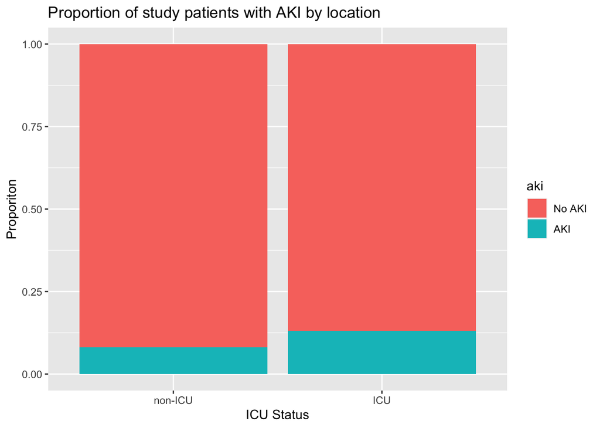

```r
ggplot(data = data.c.f, aes(x=icu, fill = aki)) +
  geom_bar(position = "fill") +
  labs(title = "Proportion of study patients with AKI by location", x = "ICU Status", y ="Proporiton" )
```

Using a Chi-square test, we can check if there is a statistically significant difference in AKI rates.

```r
# Chi-Square test
chisq.test(table(data.c$aki, data.c$icu))
```

```
##
##  Pearson's Chi-squared test with Yates' continuity correction
##
## data:  table(data.c$aki, data.c$icu)
## X-squared = 110.03, df = 1, p-value < 2.2e-16
```

At the $\alpha = 0.5$ level, we can conclude that in our study population, the AKI rates are different between non-ICU and ICU settings. This is helpful contextual information for our data, though, it is not part of the main analysis.

#### Logistic Regression and Random Forest Models

Next we create a logistic regression model for all three data subsets (complete, ICU, and non-ICU), then compare the predictors.

##### Analysis Regression for Complete Dataset

```r
N = nrow(data.c.f)
K = 10
set.seed(1234)
s = sample(1:K, size = N, replace = T)
pred.outputs.glm <- vector(mode = "numeric", length = N)
pred.outputs.rf <- vector(mode = "numeric", length = N)
obs.outputs <- vector(mode = "numeric", length = N)
offset <- 0
for(i in 1:K){
    train <-filter(data.c.f, s != i)
    test <- filter(data.c.f, s == i)
    obs.outputs[1:length(s[s == i]) + offset] <- test$aki

    #GLM train/test
    glm.aki <- glm(aki ~ ., data = train, family = binomial(logit))
  glm.predictions <- predict(glm.aki, test, type = "response")
  pred.outputs.glm[1:length(s[s == i]) + offset] <- glm.predictions

    #RF train/test
    rf <- randomForest(aki ~ ., data = train, ntree = 100, importance = TRUE)
    rf.pred.curr <- predict(rf, newdata = test, type = "prob")
    pred.outputs.rf[1:length(s[s == i]) + offset] <- rf.pred.curr[ , 2]

    offset <- offset + length(s[s == i])
}
```

```r
# AUC
roc(obs.outputs, pred.outputs.glm) # glm with cross validation
```

```
##
## Call:
## roc.default(response = obs.outputs, predictor = pred.outputs.glm)
##
## Data: pred.outputs.glm in 25255 controls (obs.outputs 1) < 2486 cases (obs.outputs 2).
## Area under the curve: 0.6933
```

```r
roc(obs.outputs, pred.outputs.rf, ci = TRUE) # rf with cross validation
```

```
##
## Call:
## roc.default(response = obs.outputs, predictor = pred.outputs.rf,     ci = TRUE)
##
## Data: pred.outputs.rf in 25255 controls (obs.outputs 1) < 2486 cases (obs.outputs 2).
## Area under the curve: 0.685
## 95% CI: 0.6742-0.6959 (DeLong)
```

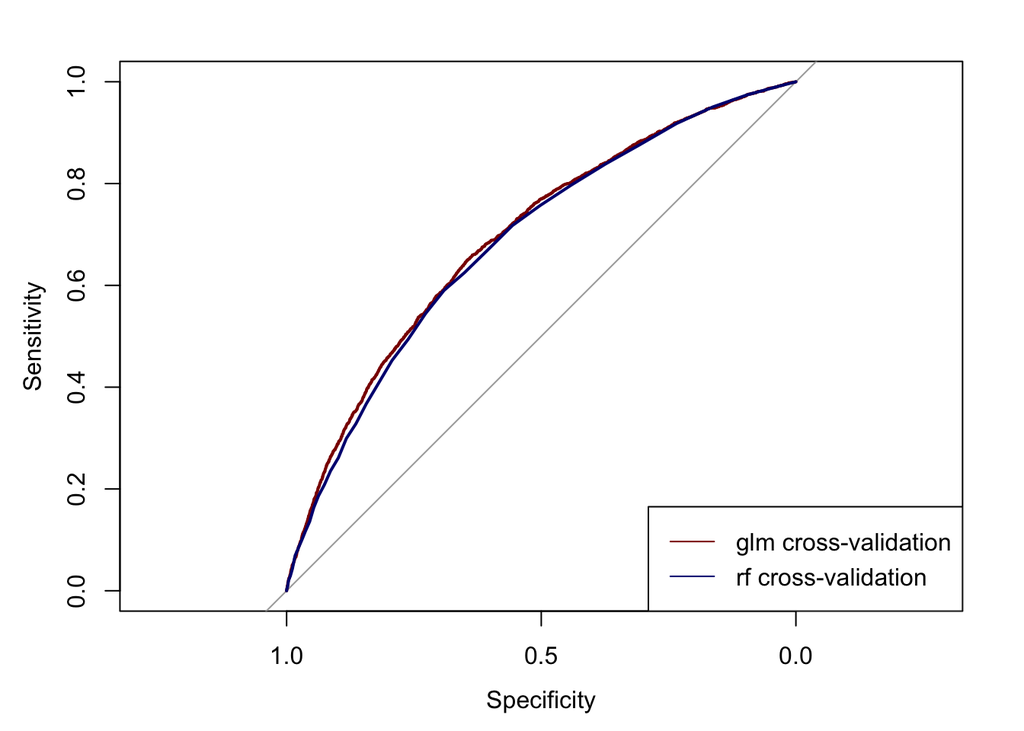

```r
# ROC Curves
plot.roc(obs.outputs, pred.outputs.glm, col = "darkred") # Glm, k fold cross validated
plot.roc(obs.outputs, pred.outputs.rf, ci = TRUE, col = "navy", add = TRUE) # RF, K-fold cross validated
legend("bottomright", legend = c("glm cross-validation", "rf cross-validation"), col = c("darkred", "navy"), lwd = 1)
```

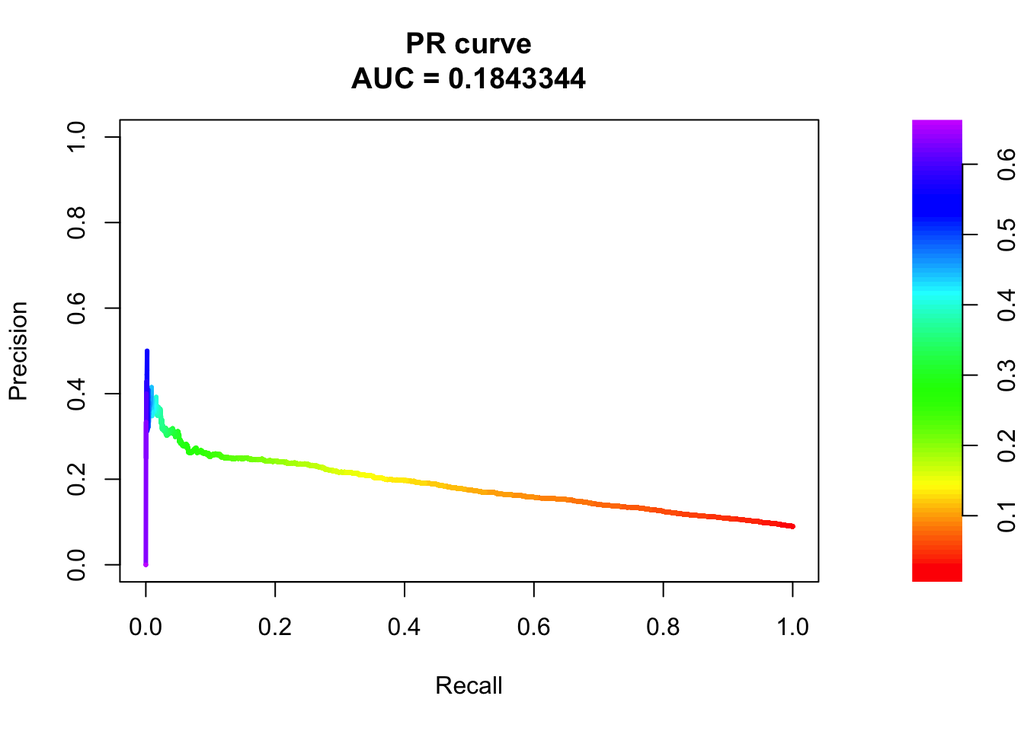

```r
# PR Curves
pr <- pr.curve(pred.outputs.glm[obs.outputs == "2"],
               pred.outputs.glm[obs.outputs == "1"], curve=TRUE)
plot(pr)
```

Next, we need to identify the top predictors

##### Mobel Building Regression for ICU Dataset

```r
N = nrow(icu)
K = 10
set.seed(1234)
s = sample(1:K, size = N, replace = T)
pred.outputs.glm.icu <- vector(mode = "numeric", length = N)
pred.outputs.rf.icu <- vector(mode = "numeric", length = N)
obs.outputs.icu <- vector(mode = "numeric", length = N)
offset <- 0
for(i in 1:K){
    train <-filter(icu, s != i)
    test <- filter(icu, s == i)
    obs.outputs.icu[1:length(s[s == i]) + offset] <- test$aki

    #GLM train/test
    glm.aki.icu <- glm(aki ~ ., data = train, family = binomial(logit))
  glm.predictions.icu <- predict(glm.aki.icu, test, type = "response")
  pred.outputs.glm.icu[1:length(s[s == i]) + offset] <- glm.predictions.icu

    #RF train/test
    rf.icu <- randomForest(aki ~ ., data = train, ntree = 100, importance = TRUE)
    rf.pred.curr.icu <- predict(rf.icu, newdata = test, type = "prob")
    pred.outputs.rf.icu[1:length(s[s == i]) + offset] <- rf.pred.curr.icu[ , 2]

    offset <- offset + length(s[s == i])
}
```

```r
#AUC
roc(obs.outputs.icu, pred.outputs.glm.icu) # glm with cross validation
```

```
##
## Call:
## roc.default(response = obs.outputs.icu, predictor = pred.outputs.glm.icu)
##
## Data: pred.outputs.glm.icu in 3923 controls (obs.outputs.icu 1) < 589 cases (obs.outputs.icu 2).
## Area under the curve: 0.6674
```

```r
roc(obs.outputs.icu, pred.outputs.rf.icu, ci = TRUE) # rf with cross validation
```

```
##
## Call:
## roc.default(response = obs.outputs.icu, predictor = pred.outputs.rf.icu,     ci = TRUE)
##
## Data: pred.outputs.rf.icu in 3923 controls (obs.outputs.icu 1) < 589 cases (obs.outputs.icu 2).
## Area under the curve: 0.6533
## 95% CI: 0.6299-0.6767 (DeLong)
```

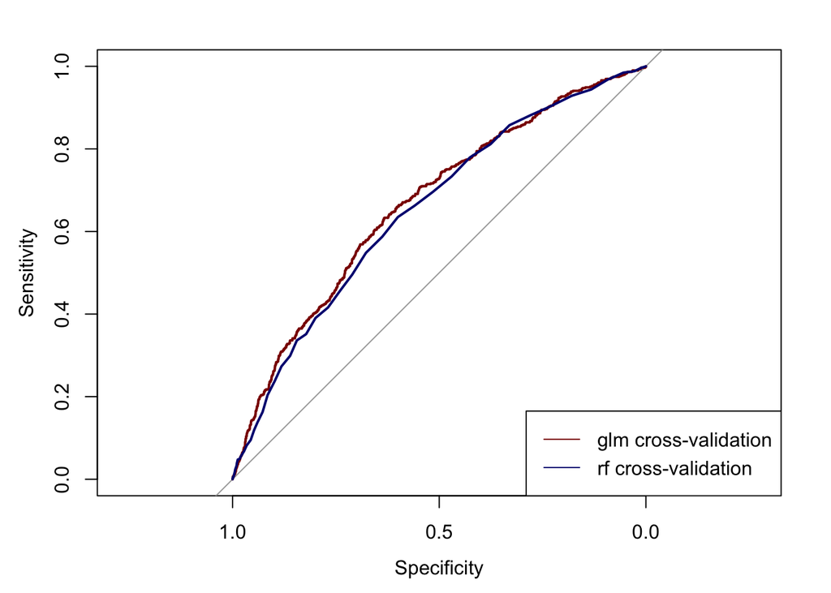

```r
#ROC Curves
plot.roc(obs.outputs.icu, pred.outputs.glm.icu, col = "darkred") # Glm, k fold cross validated
plot.roc(obs.outputs.icu, pred.outputs.rf.icu, ci = TRUE, col = "navy", add = TRUE) # RF, K-fold cross validated
legend("bottomright", legend = c("glm cross-validation", "rf cross-validation"), col = c("darkred", "navy"), lwd = 1)
```

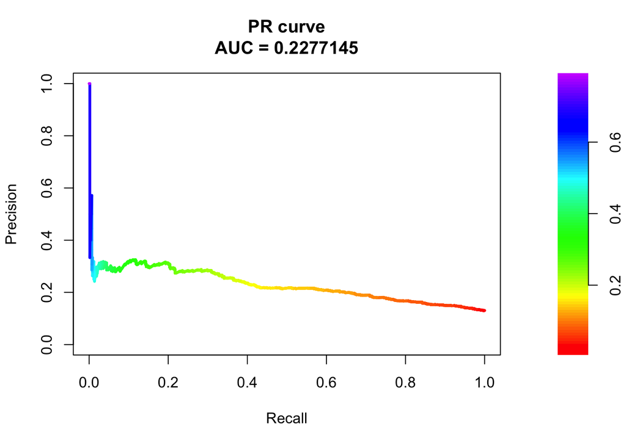

```r
# PR Curves
pr.icu <- pr.curve(pred.outputs.glm.icu[obs.outputs.icu == "2"],
               pred.outputs.glm.icu[obs.outputs.icu == "1"], curve=TRUE)
plot(pr.icu)
```

```r
N = nrow(nonicu)
K = 10
set.seed(1234)
s = sample(1:K, size = N, replace = T)
pred.outputs.glm.nonicu <- vector(mode = "numeric", length = N)
pred.outputs.rf.nonicu <- vector(mode = "numeric", length = N)
obs.outputs.nonicu <- vector(mode = "numeric", length = N)
offset <- 0
for(i in 1:K){
    train <-filter(nonicu, s != i)
    test <- filter(nonicu, s == i)
    obs.outputs.nonicu[1:length(s[s == i]) + offset] <- test$aki

    #GLM train/test
    glm.aki.nonicu <- glm(aki ~ ., data = train, family = binomial(logit))
  glm.predictions.nonicu <- predict(glm.aki.nonicu, test, type = "response")
  pred.outputs.glm.nonicu[1:length(s[s == i]) + offset] <- glm.predictions.nonicu

    #RF train/test
    rf.nonicu <- randomForest(aki ~ ., data = train, ntree = 100, importance = TRUE)
    rf.pred.curr.nonicu <- predict(rf.nonicu, newdata = test, type = "prob")
    pred.outputs.rf.nonicu[1:length(s[s == i]) + offset] <- rf.pred.curr.nonicu[ , 2]

    offset <- offset + length(s[s == i])
}
```

```r
#AUC
roc(obs.outputs.nonicu, pred.outputs.glm.nonicu) # glm with cross validation
```

```
##
## Call:
## roc.default(response = obs.outputs.nonicu, predictor = pred.outputs.glm.nonicu)
##
## Data: pred.outputs.glm.nonicu in 21332 controls (obs.outputs.nonicu 1) < 1897 cases (obs.outputs.nonicu 2).
## Area under the curve: 0.6875
```

```r
roc(obs.outputs.nonicu, pred.outputs.rf.nonicu, ci = TRUE) # rf with cross validation
```

```
##
## Call:
## roc.default(response = obs.outputs.nonicu, predictor = pred.outputs.rf.nonicu,     ci = TRUE)
##
## Data: pred.outputs.rf.nonicu in 21332 controls (obs.outputs.nonicu 1) < 1897 cases (obs.outputs.nonicu 2).
## Area under the curve: 0.676
## 95% CI: 0.6633-0.6887 (DeLong)
```

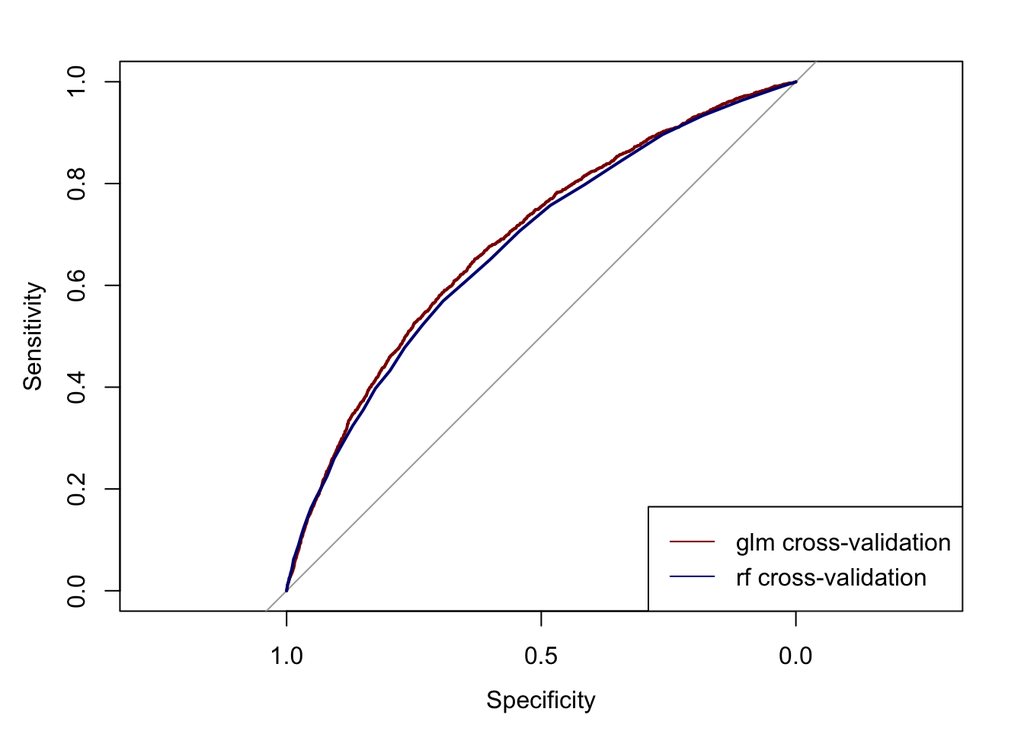

```r
#ROC Curves
plot.roc(obs.outputs.nonicu, pred.outputs.glm.nonicu, col = "darkred") # Glm, k fold cross validated
plot.roc(obs.outputs.nonicu, pred.outputs.rf.nonicu, ci = TRUE, col = "navy", add = TRUE) # RF, K-fold cross validated
legend("bottomright", legend = c("glm cross-validation", "rf cross-validation"), col = c("darkred", "navy"), lwd = 1)
```

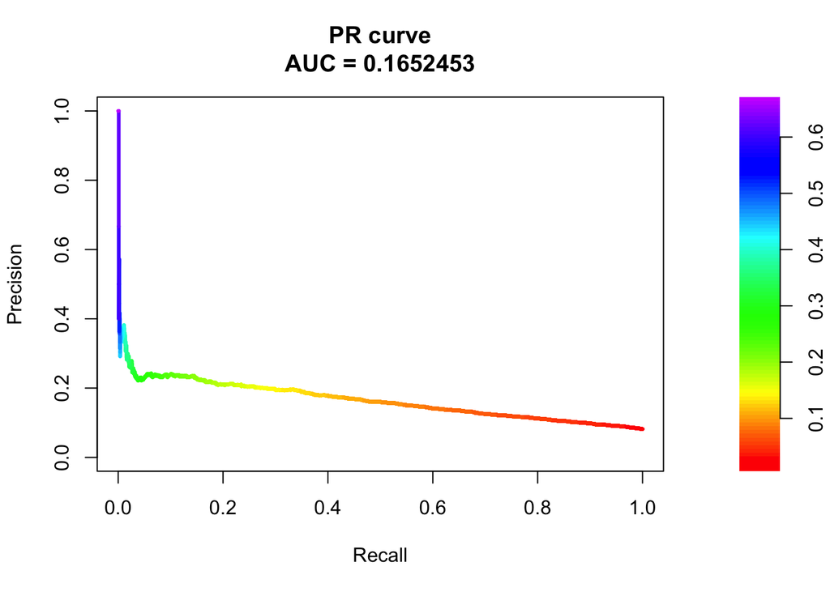

```r
# PR Curves
pr.nonicu <- pr.curve(pred.outputs.glm.nonicu[obs.outputs.nonicu == "2"],
               pred.outputs.glm.nonicu[obs.outputs.nonicu == "1"], curve=TRUE)
plot(pr.nonicu)
```

ROC performance decreased when the data was split between ICU and Non ICU, vs when data was combined. However, PRC performance increased for the ICU group. But were the top predictors different?

# Identifying top predictors

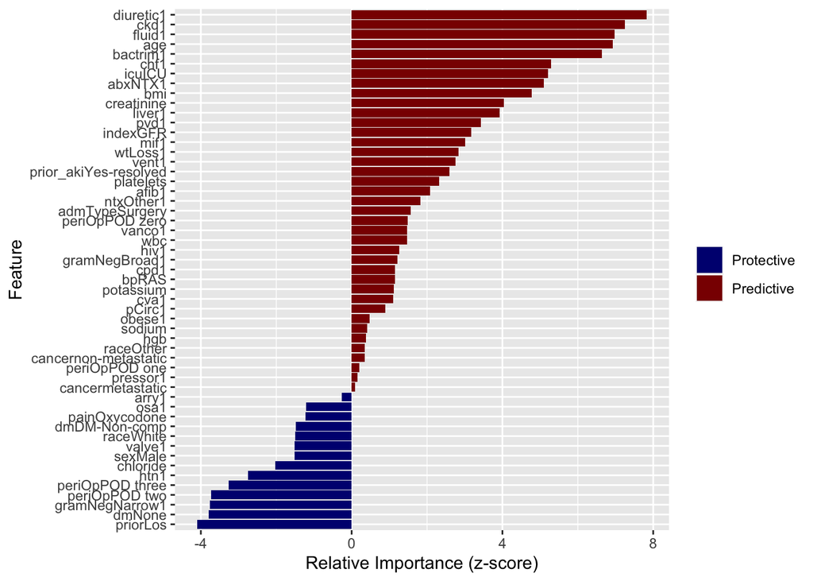

```r
# Identify top predictors for the combined data set
# Logistic Regression Importance
glm.aki.sum <- summary(glm.aki)
glm.aki.z <- data.frame(glm.aki.sum$coefficients[,3]) # make df of zscores
glm.aki.z <- rownames_to_column(glm.aki.z, "feature") # convert rownames to a column
glm.aki.z <- glm.aki.z[!(glm.aki.z$feature=="(Intercept)"),] # drop intercept
colnames(glm.aki.z)[2] <- "z" # rename column to z
glm.aki.z$col.flag <- glm.aki.z$z>0 # Create a color flag
ggplot(glm.aki.z, aes(x = reorder(feature, z), y = z, fill = col.flag)) +
  geom_bar(stat = "identity") +
  coord_flip() +
  scale_fill_manual(values = c("navy", "darkred"), name = NULL, labels = c("Protective", "Predictive"))+
  labs(y="Relative Importance (z-score)", x = "Feature")
```

```r
#Get 10 Top Predictors by GLM
glm.aki.pvals <- data.frame(glm.aki.sum$coefficients[,4])
top.glm.aki.pvals <- glm.aki.pvals %>%
  filter(rownames(glm.aki.pvals) != "(Intercept)") %>%
  arrange(glm.aki.sum.coefficients...4.) %>%
  slice_head(n=10)

# Evaluate change in deviance?
anova(glm.aki)
```

```
## Analysis of Deviance Table
##
## Model: binomial, link: logit
##
## Response: aki
##
## Terms added sequentially (first to last)
##
##
##               Df Deviance Resid. Df Resid. Dev
## NULL                          24924      15066
## pain           1    6.876     24923      15060
## bp             1    8.141     24922      15051
## sex            1    0.102     24921      15051
## race           2   13.072     24919      15038
## admType        1    1.643     24918      15037
## periOp         4   75.810     24914      14961
## icu            1   91.144     24913      14870
## vent           1   20.761     24912      14849
## chf            1  215.303     24911      14634
## cpd            1   15.273     24910      14618
## hiv            1    2.480     24909      14616
## liver          1   18.063     24908      14598
## pvd            1   39.255     24907      14558
## cva            1    5.806     24906      14553
## mif            1   16.710     24905      14536
## valve          1    0.041     24904      14536
## htn            1    0.039     24903      14536
## arry           1    1.816     24902      14534
## pCirc          1    3.905     24901      14530
## obese          1    6.032     24900      14524
## wtLoss         1   14.432     24899      14510
## fluid          1   71.056     24898      14439
## ckd            1  108.341     24897      14330
## afib           1   10.638     24896      14320
## osa            1    0.176     24895      14320
## dm             2   33.479     24893      14286
## cancer         2    0.455     24891      14286
## prior_aki      1    2.449     24890      14283
## vanco          1    7.763     24889      14275
## bactrim        1   40.604     24888      14235
## pressor        1    1.715     24887      14233
## ntxOther       1    0.646     24886      14232
## abxNTX         1   30.535     24885      14202
## diuretic       1   66.446     24884      14136
## gramNegBroad   1    2.240     24883      14133
## gramNegNarrow  1   14.369     24882      14119
## age            1   34.519     24881      14084
## bmi            1   14.889     24880      14069
## priorLos       1   19.183     24879      14050
## wbc            1    5.117     24878      14045
## hgb            1    0.046     24877      14045
## platelets      1    8.396     24876      14037
## sodium         1    0.943     24875      14036
## potassium      1    1.894     24874      14034
## chloride       1    4.304     24873      14030
## creatinine     1    6.611     24872      14023
## indexGFR       1    9.643     24871      14013
```

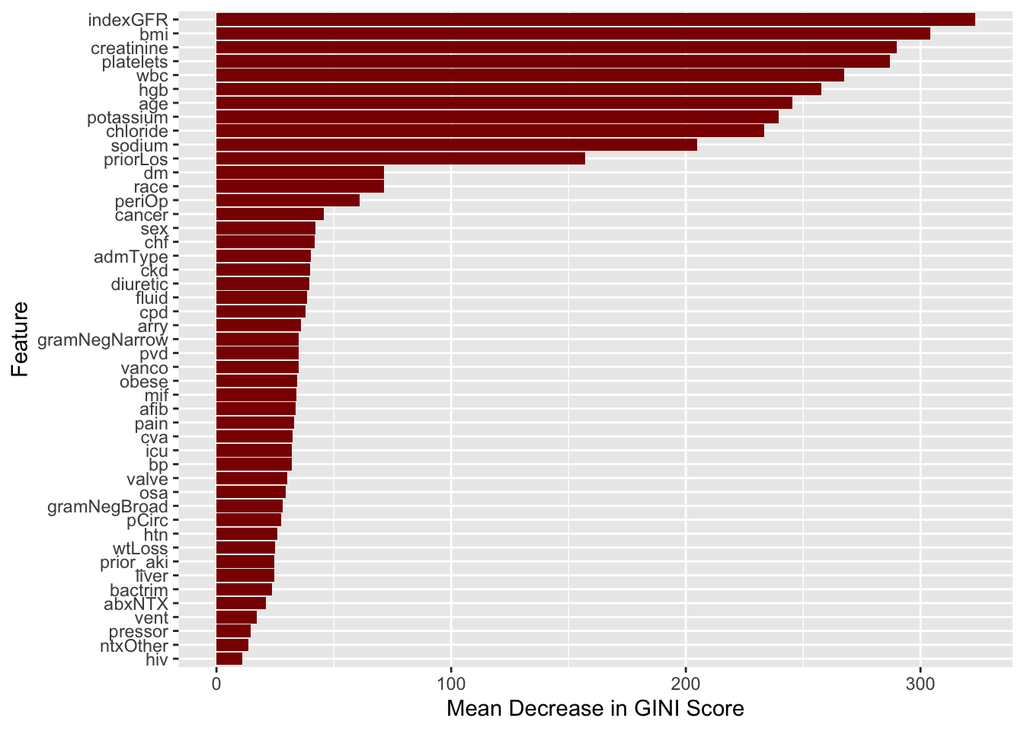

```r
# Random Forest Importance
gini <- as.data.frame(rf$importance)
gini <- rownames_to_column(gini, "feature") # convert rownames to a column
ggplot(gini, aes(x = reorder(feature, MeanDecreaseGini) , y = MeanDecreaseGini))+
  geom_bar(stat = "identity", fill = "darkred") +
  coord_flip()+
  labs(y="Mean Decrease in GINI Score", x = "Feature")
```

```r
# Get 10 top Predictors by RF (highest decrease in GINI)
top.rf.gini = gini %>%
  arrange(desc(MeanDecreaseGini)) %>%
  slice_head(n=10)
```

Repeat process for ICU subset

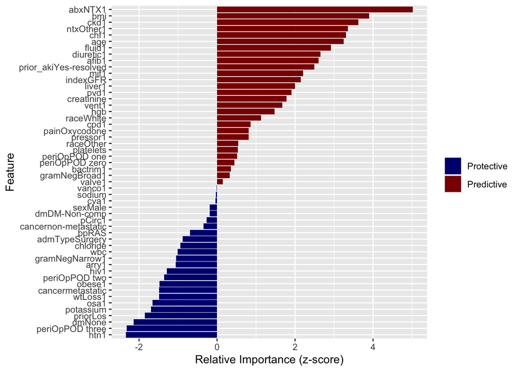

```r
# Identify top predictors for the icu sub set
# Logistic Regression Importance
glm.aki.sum.icu <- summary(glm.aki.icu)
glm.aki.z.icu <- data.frame(glm.aki.sum.icu$coefficients[,3]) # make df of zscores
glm.aki.z.icu <- rownames_to_column(glm.aki.z.icu, "feature") # convert rownames to a column
glm.aki.z.icu <- glm.aki.z.icu[!(glm.aki.z.icu$feature=="(Intercept)"),] # drop intercept
colnames(glm.aki.z.icu)[2] <- "z" # rename column to z
glm.aki.z.icu$col.flag <- glm.aki.z.icu$z>0 # Create a color flag
ggplot(glm.aki.z.icu, aes(x = reorder(feature, z), y = z, fill = col.flag)) +
  geom_bar(stat = "identity") +
  coord_flip() +
  scale_fill_manual(values = c("navy", "darkred"), name = NULL, labels = c("Protective", "Predictive"))+
  labs(y="Relative Importance (z-score)", x = "Feature")
```

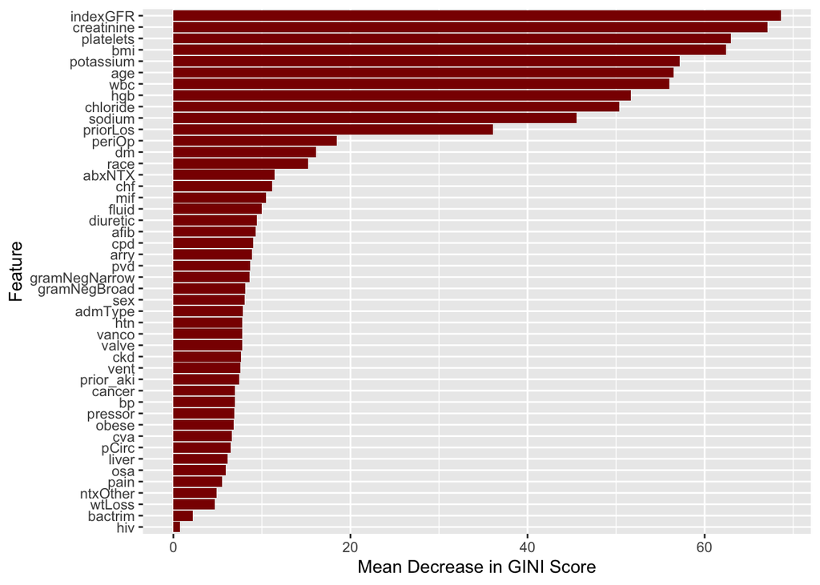

```r
#Get 10 Top Predictors by GLM
glm.aki.pvals.icu <- data.frame(glm.aki.sum.icu$coefficients[,4])
top.glm.aki.pvals.icu <- glm.aki.pvals.icu %>%
  filter(rownames(glm.aki.pvals.icu) != "(Intercept)") %>%
  arrange(glm.aki.sum.icu.coefficients...4.) %>%
  slice_head(n=10)

# Random Forest Importance
gini.icu <- as.data.frame(rf.icu$importance)
gini.icu <- rownames_to_column(gini.icu, "feature") # convert rownames to a column
ggplot(gini.icu, aes(x = reorder(feature, MeanDecreaseGini) , y = MeanDecreaseGini))+
  geom_bar(stat = "identity", fill = "darkred") +
  coord_flip()+
  labs(y="Mean Decrease in GINI Score", x = "Feature")
```

```r
# Get 10 top Predictors by RF (highest decrease in GINI)
top.rf.gini.icu = gini.icu %>%
  arrange(desc(MeanDecreaseGini)) %>%
  slice_head(n=10)
```

Repeat process for non-ICU subset

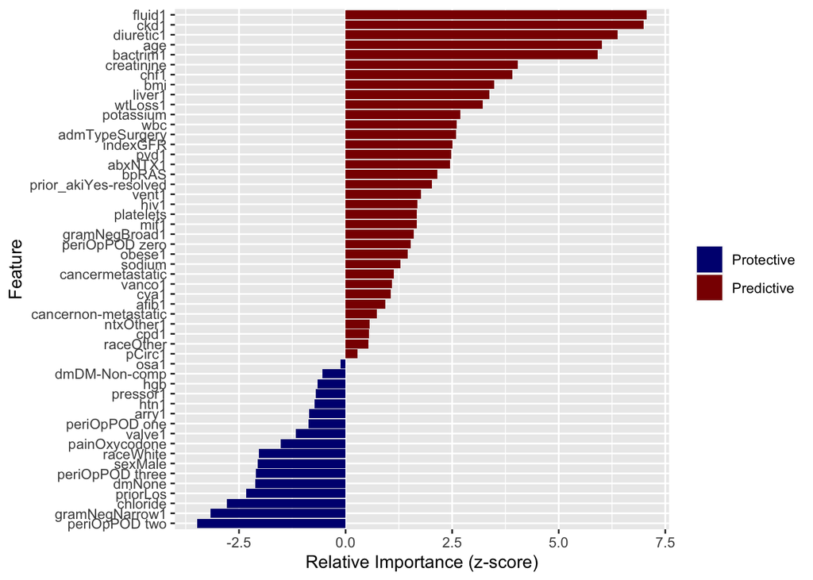

```r
# Identify top predictors for the icu sub set
# Logistic Regression Importance
glm.aki.sum.nonicu <- summary(glm.aki.nonicu)
glm.aki.z.nonicu <- data.frame(glm.aki.sum.nonicu$coefficients[,3]) # make df of zscores
glm.aki.z.nonicu <- rownames_to_column(glm.aki.z.nonicu, "feature") # convert rownames to a column
glm.aki.z.nonicu <- glm.aki.z.nonicu[!(glm.aki.z.nonicu$feature=="(Intercept)"),] # drop intercept
colnames(glm.aki.z.nonicu)[2] <- "z" # rename column to z
glm.aki.z.nonicu$col.flag <- glm.aki.z.nonicu$z>0 # Create a color flag
ggplot(glm.aki.z.nonicu, aes(x = reorder(feature, z), y = z, fill = col.flag)) +
  geom_bar(stat = "identity") +
  coord_flip() +
  scale_fill_manual(values = c("navy", "darkred"), name = NULL, labels = c("Protective", "Predictive"))+
  labs(y="Relative Importance (z-score)", x = "Feature")
```

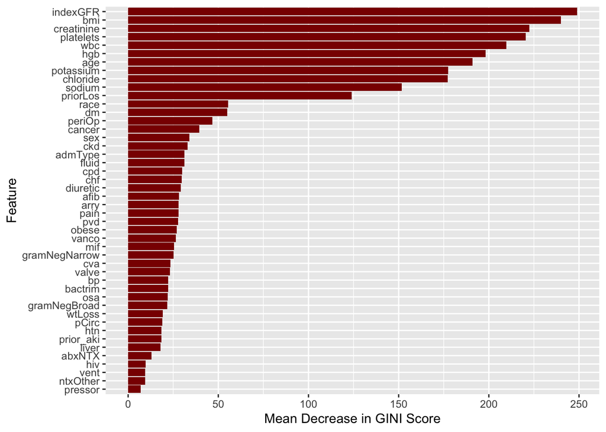

```r
#Get 10 Top Predictors by GLM
glm.aki.pvals.nonicu <- data.frame(glm.aki.sum.nonicu$coefficients[,4])
top.glm.aki.pvals.nonicu <- glm.aki.pvals.nonicu %>%
  filter(rownames(glm.aki.pvals.nonicu) != "(Intercept)") %>%
  arrange(glm.aki.sum.nonicu.coefficients...4.) %>%
  slice_head(n=10)

# Random Forest Importance
gini.nonicu <- as.data.frame(rf.nonicu$importance)
gini.nonicu <- rownames_to_column(gini.nonicu, "feature") # convert rownames to a column
ggplot(gini.nonicu, aes(x = reorder(feature, MeanDecreaseGini) , y = MeanDecreaseGini))+
  geom_bar(stat = "identity", fill = "darkred") +
  coord_flip()+
  labs(y="Mean Decrease in GINI Score", x = "Feature")
```

```r
# Get 10 top Predictors by RF (highest decrease in GINI)
top.rf.gini.nonicu = gini.nonicu %>%
  arrange(desc(MeanDecreaseGini)) %>%
  slice_head(n=10)
```

Make a table that compare the top predictors for the different methods and the different datasets.

```r
# Make a dataframe with all the results

top.compare.pval <-data.frame(rownames(top.glm.aki.pvals), rownames(top.glm.aki.pvals.nonicu),  rownames(top.glm.aki.pvals.icu)) %>%
  rename("combined" = 1, "non-ICU" =2, "ICU" = 3)
top.compare.pval
```

```
##     combined       non-ICU                   ICU
## 1  diuretic1        fluid1               abxNTX1
## 2       ckd1          ckd1                   bmi
## 3     fluid1     diuretic1                  ckd1
## 4        age           age             ntxOther1
## 5   bactrim1      bactrim1                  chf1
## 6       chf1    creatinine                   age
## 7     icuICU          chf1                fluid1
## 8    abxNTX1           bmi             diuretic1
## 9        bmi periOpPOD two                 afib1
## 10  priorLos        liver1 prior_akiYes-resolved
```

```r
top.compare.gini <-data.frame(top.rf.gini$feature,  top.rf.gini.nonicu$feature, top.rf.gini.icu$feature)
top.compare.gini
```

```
##    top.rf.gini.feature top.rf.gini.nonicu.feature top.rf.gini.icu.feature
## 1             indexGFR                   indexGFR                indexGFR
## 2                  bmi                        bmi              creatinine
## 3           creatinine                 creatinine               platelets
## 4            platelets                  platelets                     bmi
## 5                  wbc                        wbc               potassium
## 6                  hgb                        hgb                     age
## 7                  age                        age                     wbc
## 8            potassium                  potassium                     hgb
## 9             chloride                   chloride                chloride
## 10              sodium                     sodium                  sodium
```

Gini score is sensitive variables that have lots of categories or are continuous. These scores are inflated and picking the top ten, may lead to selecting the same continuous variables across each hospital setting. One way around this is to convert continuous variables to discrete variables. In this setting, this could be done by flagging abnormal values, as EHRS often do for clinicians. Can create a flag variables, and repeat the experiment with all the continuous variables converted to categorical variables.

Mean Decrease in Accuracy has a problem: when variables are dependent on each tother, you cant tell if either is important.

# References

1. Goyal A, Daneshpajouhnejad P, Hashmi MF, et al. Acute Kidney Injury. [Updated 2022 Aug 18]. In: StatPearls [Internet]. Treasure Island (FL): StatPearls Publishing; 2022 Jan-. Available from: https://www.ncbi.nlm.nih.gov/books/NBK441896/.
2. De Vlieger, Greeta; Kashani, Kianoushb; Meyfroidt, Geerta. Artificial intelligence to guide management of acute kidney injury in the ICU: a narrative review. Current Opinion in Critical Care: December 2020 - Volume 26 - Issue 6 - p 563-573 doi: 10.1097/MCC.0000000000000775.
3. Miano, Todd A., et al. “Effect of renin-angiotensin system inhibitors on the comparative nephrotoxicity of NSAIDs and opioids during hospitalization.” Kidney360 1.7 (2020): 604.